# Portfolio 6: visualising uncertainty (frequentist and Bayesian)

161.307 Reproducible Visualisation for Statistics

Author

School of Mathematical and Computational Sciences, Massey University

Published

19 Aug 2026

# Requirements

1. Download the `portfolio06_student.qmd` template file. Make sure you include your name and student ID in the file name and within the document.
2. Answer the questions below.

# Portfolio text and questions

This portfolio partly builds on Portfolio 5. You may re-use the same random process/ensemble from that portfolio, **or** start fresh with a simple quantity of your choice (a regression fit, a bootstrap distribution of a mean/proportion, etc.).

## Part A: encoding the same uncertainty two ways

Produce **Two different uncertainty encodings**, drawn from *different* families covered in Week 6 lectures, of the *same* quantity. For example error bars vs. a ribbon band, a graded fan chart vs. a quantile dotplot, or a violin plot vs. a (correctly captioned, non-“dynamite”) summary plot. (do not simply repeat the spaghetti/ribbon pair from Portfolio 5)

Both plot must **explicitly label** what the interval represents (SD? SE? Quantiles? At which level?). We consider that an unlabelled interval is an incomplete answer, regardless of how polished the plot looks.

## Part B: reading a Bayesian plot

No prior Bayesian knowledge or modelling is required for this part. The code and plot below are provided fully worked, ready to run as-is. In case you have not encountered this type of analysis before:

- Suppose you are estimating the success rate of a basketball free-throw shooter. You have observed 7 successes out of 10 trials. The *frequentist* approach treats the “true” proportion as a fixed, unknown number and builds a confidence interval around your maximum likelihood estimate (7/10 = 0.7). The *Bayesian approach* instead treats the *proportion itself* as uncertain, and describes that uncertainty with a probability distribution.
- **The prior.** Before seeing any data, we state a starting belief about plausible values of the proportion, as a distribution. Here, for simplicity, we use a fairly non-committal Beta(2,2) prior. Our **prior** on the success rate of free-throws for that shooter states that all values between 0 and 1 are plausible and those close to 0.5 are the most plausible ones.
- **The update.** We combine the prior with the observed data (7/10) using Bayes’ rule. For the simple proportion problem at hand, the maths allow us to derive a closed-form solution (“Beta-Binomial” model), with no simulation or fitting (e.g. relying on MCMC techniques) required.
- **The posterior.** The result is an updated distribution over plausible values of the proportion *after having sen the data* coined the **posterior**. It is narrower than the prior (we’ve learned something from the data) and centred a bit away from the empirical 0.7.
- **The plot.** Because the posterior is a probability distribution, we can visualise it exactly the same way we visualised the bootstrap distribution earlier this week in the lectures: we draw samples from this posterior distribution, and show those samples as a **quantile dotplot**. Each dot below is one plausible value of the true proportion, in the same “equally-likely outcome” sense as seen in the lectures; the *only* thing that has changed is that these draws come from a posterior distribution instead of a bootstrapped distribution.

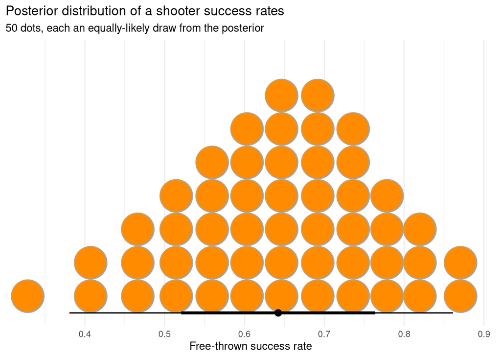

```r
library(ggdist)
library(ggplot2)

# Worked example: Beta(2,2) prior updated with 7 successes out of 10 trials
# The posterior is a Beta(2 + 7, 2 + 3) = Beta(9, 5) distribution.
# This is provided for you, no modelling required.
set.seed(2026)
posterior_draws <- rbeta(10000, 9, 5)

data.frame(value = posterior_draws) |>
  ggplot(aes(x = value)) +
  stat_dotsinterval(quantiles = 50, fill = "darkorange",
                     point_interval = "mean_qi") +
  scale_y_continuous(NULL, breaks = NULL) +
  labs(title = "Posterior distribution of a shooter success rates",
       subtitle = "50 dots, each an equally-likely draw from the posterior",
       x = "Free-thrown success rate") +
  theme_minimal()
```

Answer, in your commentary:

- This plot uses the *same* quantile-dotplot technique as the bootstrap example in lecture. What has changed about what each dot *represents*?
- The shaded interval under the dots is a 95% **credible interval** (aka compatibility interval), not a confidence interval. In a sentence or two, what is the (correct) interpretation of a credible interval, and how does it differ from the interpretation of a confidence interval (you may have shown in Part A)? Feel free to refer to Chapter 16 of Wilke’s *Fundamentals of Data Visualization* (2019), p194-197.

## Written commentary (~150 words; code, figures, tables not included)

- What does each Part A encoding communicate that the other does not?
- For *your chosen quantity*, which of your Part A plots would you show to
  1. a technical audience familiar with the model, and (b) a general audience? Why?
- Your answers to the two Part B questions above.
- Reference at least one relevant point from [Wilke (2019)](http://clauswilke.com/dataviz/) or the [Handbook of Data Visualization](https://haralick.org/DV/Handbook_of_Data_Visualization.pdf) to support your reasoning.

Apply consistent styling (theme, colours, fonts) across your Part A plots. Submit the Quarto (.qmd) file and the rendered document (`.html` or `.pdf`), which should show both code and output.

**Our expectation is this should take you approximately one hour**. Part B requires no modelling on your part. You are asked to run the provided chunk and interpret the resulting plot.

# Template file

Available [here `portfolio06_student.qmd`](https://github.com/MatthieuVignes/161307Massey/raw/refs/heads/main/portfolio06_student.qmd) or on Stream.